# Case 31: Summary of Data Analysis for R3, R6, and R4

Employees Federal Credit Union | R3, R6, R4a, R4b, and R4c

Author

Julieta Diaz

Published

November 12, 2026

# Overview

This report answers five Case 31 research questions. For each one I look at the **descriptive statistics first** to find the story, then use an inferential test to confirm it; test statistics appear in parentheses so they do not get in the way of the insight.

Table 1: Research questions in this report

| RQ | Question | Variables | Analysis |
| --- | --- | --- | --- |
| **R3** | What are members’ attitudes toward the proficiency of CU employees? | `att_employee` (mean of Q3 to Q6) | Descriptives, one-sample *t*-test |
| **R6** | How effectively do members believe the CU is operated? | Q9r, Q10r, Q31 to Q34, Q37r; Q11, Q12 | Descriptives, one-sample *t*-tests; chi-square goodness-of-fit |
| **R4a** | Do HQ-area and other members differ in attitude toward employees? | Q38 by `att_employee` | Independent-samples *t*-test |
| **R4b** | Do they differ in awareness of services? | Q38 by Q13r to Q26r | Cross-tabulation, chi-square test of independence |
| **R4c** | Do they differ in perceived operational effectiveness? | Q38 by the R6 items | Independent *t*-tests; chi-square tests |

**Decisions carried over from the reliability and factor analysis**

My previous report found that **R3’s items (Q3 to Q6) are valid and reliable** (α = .87), so they are averaged into one composite, `att_employee`. **R6’s items (Q31 to Q34) are not** (α = .47, no single factor), so each R6 item is analyzed **separately**. Those analyses are not repeated here.

# 1 Data Preparation

**Show the R code**

```r
library(tidyverse)
library(haven)
library(knitr)

efcu <- read_sav("data/Case 31 Data_efcu_1.sav") |>
  zap_labels() |>
  mutate(
    q12  = if_else(q12 == 3, NA, q12),                 # 3 = no answer
    q9r  = 6 - q9,                                     # 1 = never ... 5 = too often
    q10r = 5 - q10,                                    # 1 = poor ... 4 = excellent
    q37r = 6 - q37,                                    # 1 = very poor ... 5 = excellent
    across(q13:q26, ~ 4 - .x, .names = "{.col}r"),     # 1 = unaware ... 3 = aware and used
    att_employee = rowMeans(across(q3:q6)),            # R3 composite (alpha = .87)
    residence = factor(q38, levels = 1:2,
                       labels = c("HQ area", "Elsewhere"))
  )

count(efcu, residence)
```

| residence | n |
| --- | --- |
| HQ area | 57 |
| Elsewhere | 71 |

**Show the R code**

```r
fmt_p <- function(p) ifelse(p < .001, "< .001", paste("=", sub("^0", "", sprintf("%.3f", p))))
fmt_p_tbl <- function(p) ifelse(p < .001, "<.001", sprintf("%.3f", p))

# One-sample t-test summary row
t1 <- function(x, mu, item) {
  tt <- t.test(x, mu = mu)
  tibble(Item = item, n = sum(!is.na(x)), Mean = mean(x, na.rm = TRUE),
         SD = sd(x, na.rm = TRUE), `Test value` = mu,
         t = unname(tt$statistic), df = unname(tt$parameter), p = tt$p.value)
}

# Independent-samples (Welch) t-test summary row by residence
t2 <- function(var, item) {
  x <- efcu[[var]]
  tt <- t.test(x ~ efcu$residence)
  m <- tapply(x, efcu$residence, mean, na.rm = TRUE)
  tibble(Item = item, `HQ area M` = m[["HQ area"]], `Elsewhere M` = m[["Elsewhere"]],
         Difference = m[["HQ area"]] - m[["Elsewhere"]],
         t = unname(tt$statistic), df = unname(tt$parameter), p = tt$p.value)
}

r6_labels <- c(
  q9r  = "Q9r: Statement frequency (1 = never, 5 = too often)",
  q10r = "Q10r: Statement accuracy (1 = poor, 4 = excellent)",
  q31  = "Q31: Keeps my financial information confidential",
  q32  = "Q32: Prompt in processing loans",
  q33  = "Q33: Services meet members' needs",
  q34  = "Q34: Loan applications are simple",
  q37r = "Q37r: Overall management (1 = very poor, 5 = excellent)"
)
r6_mid <- c(q9r = 3, q10r = 2.5, q31 = 3, q32 = 3, q33 = 3, q34 = 3, q37r = 3)

pal <- c("#6B2737", "#C99AA5", "#CFE3F1")
```

The sample has 128 members: 57 live in the headquarters area and 71 live elsewhere.

# 2 R3: Attitude toward Employee Proficiency

## 2.1 R3: Descriptive Statistics

**Show the R code**

```r
r3_items <- c(q3 = "Q3: Courteous", q4 = "Q4: Helpful",
              q5 = "Q5: Professional", q6 = "Q6: Always available")

r3_desc <- map_dfr(names(r3_items), function(v) {
  x <- efcu[[v]]
  tibble(Item = r3_items[[v]], Mean = mean(x), SD = sd(x),
         `Agree or strongly agree (%)` = 100 * mean(x >= 4))
}) |>
  bind_rows(tibble(Item = "**att_employee (composite)**",
                   Mean = mean(efcu$att_employee), SD = sd(efcu$att_employee),
                   `Agree or strongly agree (%)` = 100 * mean(efcu$att_employee >= 4)))

r3_desc |> mutate(across(where(is.numeric), ~ round(.x, 2)))
```

Table 2: Attitude toward employees: item and composite descriptives (1 = strongly disagree, 5 = strongly agree)

| Item | Mean | SD | Agree or strongly agree (%) |
| --- | --- | --- | --- |
| Q3: Courteous | 4.35 | 0.66 | 89.84 |
| Q4: Helpful | 4.31 | 0.70 | 88.28 |
| Q5: Professional | 4.08 | 0.66 | 82.03 |
| Q6: Always available | 4.08 | 0.79 | 78.91 |
| **att_employee (composite)** | 4.21 | 0.59 | 75.78 |

**Show the R code**

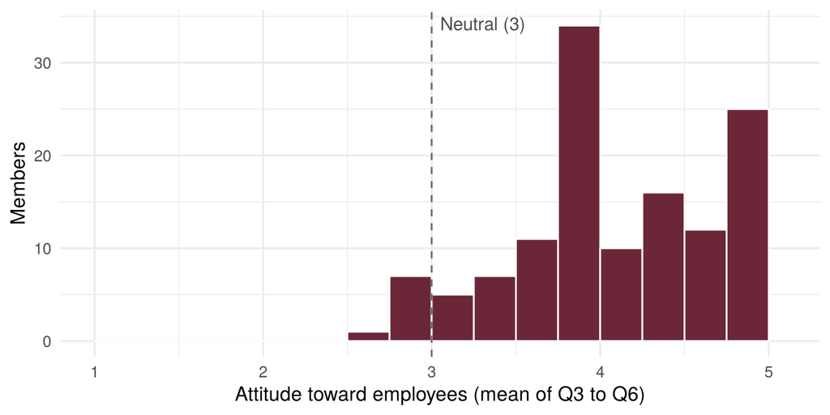

Figure 1: Distribution of the attitude toward employees composite

```r
ggplot(efcu, aes(att_employee)) +
  geom_histogram(binwidth = 0.25, fill = pal[1], color = "white", boundary = 0) +
  geom_vline(xintercept = 3, linetype = "dashed", color = "grey40") +
  annotate("text", x = 3.05, y = Inf, label = "Neutral (3)", vjust = 1.5, hjust = 0, color = "grey30") +
  scale_x_continuous(limits = c(1, 5.1), breaks = 1:5) +
  labs(x = "Attitude toward employees (mean of Q3 to Q6)", y = "Members") +
  theme_minimal(base_size = 12)
```

## 2.2 R3: One-Sample t-Test

**Show the R code**

```r
r3_t <- t1(efcu$att_employee, 3, "att_employee")
r3_t |> mutate(across(c(Mean, SD, t), ~ round(.x, 2)), p = fmt_p_tbl(p))
```

Table 3: One-sample t-test of att_employee against the neutral midpoint (3)

| Item | n | Mean | SD | Test value | t | df | p |
| --- | --- | --- | --- | --- | --- | --- | --- |
| att_employee | 128 | 4.21 | 0.59 | 3 | 22.95 | 127 | <.001 |

**R3 Insight**

Members have a **very positive** view of credit union employees. The average attitude is **4.21** on a 5-point scale, and **76%** of members average “agree” or higher (Table 2, Figure 1); only 1 of 128 members has an average below neutral. The rating is far above the neutral midpoint (*t*(127) = 22.95, *p* < .001). Employees are seen as most **courteous** (4.35) and **helpful** (4.31), while being **professional** and **always available** are rated lowest (both 4.08), so professionalism and staff availability are the areas with the most room to improve. Employees are a strength the CU can feature when promoting its loans.

# 3 R6: Operational Effectiveness

## 3.1 R6: Descriptive Statistics and One-Sample t-Tests

**Show the R code**

```r
r6_t <- map_dfr(names(r6_labels), \(v) t1(efcu[[v]], r6_mid[[v]], r6_labels[[v]]))
r6_t |> mutate(across(c(Mean, SD, t), ~ round(.x, 2)), df = round(df), p = fmt_p_tbl(p))
```

Table 4: Operational effectiveness items: descriptives and one-sample t-tests against each scale’s midpoint

| Item | n | Mean | SD | Test value | t | df | p |
| --- | --- | --- | --- | --- | --- | --- | --- |
| Q9r: Statement frequency (1 = never, 5 = too often) | 128 | 2.77 | 0.42 | 3.0 | -6.10 | 127 | <.001 |
| Q10r: Statement accuracy (1 = poor, 4 = excellent) | 128 | 3.47 | 0.64 | 2.5 | 17.15 | 127 | <.001 |
| Q31: Keeps my financial information confidential | 128 | 3.95 | 0.68 | 3.0 | 15.74 | 127 | <.001 |
| Q32: Prompt in processing loans | 128 | 3.72 | 0.79 | 3.0 | 10.25 | 127 | <.001 |
| Q33: Services meet members’ needs | 128 | 3.59 | 0.68 | 3.0 | 9.87 | 127 | <.001 |
| Q34: Loan applications are simple | 128 | 3.46 | 0.78 | 3.0 | 6.66 | 127 | <.001 |
| Q37r: Overall management (1 = very poor, 5 = excellent) | 121 | 4.07 | 0.73 | 3.0 | 16.12 | 120 | <.001 |

**Show the R code**

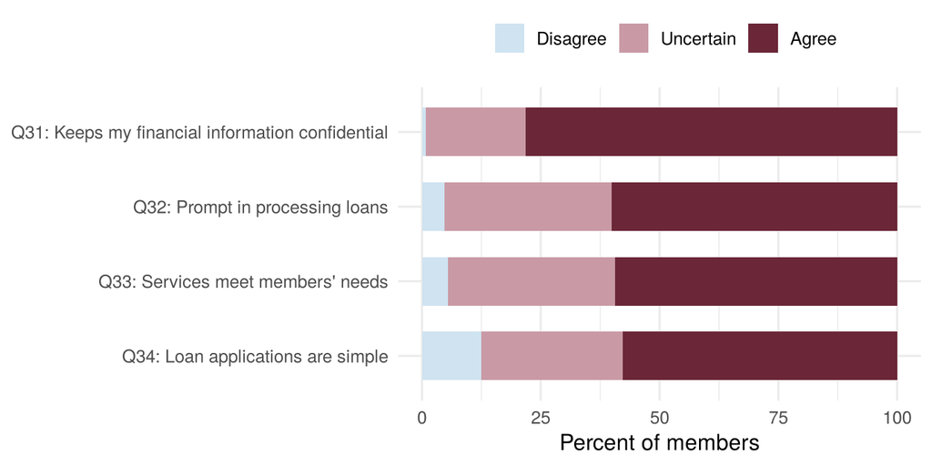

Figure 2: Agreement with the operational effectiveness statements (Q31 to Q34)

```r
efcu |>
  select(q31:q34) |>
  pivot_longer(everything(), names_to = "item", values_to = "value") |>
  mutate(item = r6_labels[item],
         Response = factor(case_when(value <= 2 ~ "Disagree", value == 3 ~ "Uncertain",
                                     TRUE ~ "Agree"),
                           levels = c("Disagree", "Uncertain", "Agree"))) |>
  count(item, Response) |>
  group_by(item) |> mutate(pct = 100 * n / sum(n)) |> ungroup() |>
  ggplot(aes(pct, fct_rev(item), fill = fct_rev(Response))) +
  geom_col(width = 0.65) +
  scale_fill_manual(values = c(Agree = pal[1], Uncertain = pal[2], Disagree = pal[3]),
                    breaks = c("Disagree", "Uncertain", "Agree")) +
  labs(x = "Percent of members", y = NULL, fill = NULL) +
  theme_minimal(base_size = 12) + theme(legend.position = "top")
```

## 3.2 R6: Chi-Square Goodness-of-Fit Tests (Q11, Q12)

**Show the R code**

```r
r6_gof <- map_dfr(c(q11 = "Q11: Statements easy to understand",
                    q12 = "Q12: CU keeps account information confidential") |> imap(\(lab, v) c(v, lab)),
  function(x) {
    tab <- table(factor(efcu[[x[1]]], 1:2))
    chi <- chisq.test(tab)
    tibble(Item = x[2], n = sum(tab), `Yes (%)` = round(100 * tab[1] / sum(tab), 1),
           `No (%)` = round(100 * tab[2] / sum(tab), 1),
           `χ²(1)` = round(unname(chi$statistic), 2), p = fmt_p_tbl(chi$p.value))
  })
r6_gof
```

Table 5: Yes/no items: frequencies and chi-square goodness-of-fit tests against a 50/50 split

| Item | n | Yes (%) | No (%) | χ²(1) | p |
| --- | --- | --- | --- | --- | --- |
| Q11: Statements easy to understand | 128 | 97.7 | 2.3 | 116.28 | <.001 |
| Q12: CU keeps account information confidential | 106 | 69.8 | 30.2 | 16.64 | <.001 |

**R6 Insight**

Members believe the credit union is **well run**. **84%** rate overall management as good or excellent (*M* = 4.07, *t*(120) = 16.12, *p* < .001), statements are seen as accurate and easy to understand (97.7% yes), and members agree the CU keeps information confidential, processes loans promptly, meets their needs, and keeps applications simple (all *p* < .001, Table 4, Figure 2). Two areas deserve attention:

- **Statement frequency** falls slightly *below* “about right” (*M* = 2.77, *p* < .001): about one in four members say they do not get statements often enough.
- **Privacy:** although members agree with Q31 on average, **30.2%** answered *no* when asked directly whether account information is kept confidential (Q12).

**Loan applications** being simple (Q34) is the lowest-rated of the four agreement items, which matters for a credit union that wants members to borrow more.

# 4 R4: Headquarters-Area Members vs. Members Elsewhere

## 4.1 R4a: Attitude toward Employees

**Show the R code**

```r
r4a <- t2("att_employee", "att_employee (1 to 5)")
r4a |> mutate(across(where(is.numeric) & !df, ~ round(.x, 2)), df = round(df, 1), p = fmt_p_tbl(p))
```

Table 6: Attitude toward employees by residence: independent-samples (Welch) t-test

| Item | HQ area M | Elsewhere M | Difference | t | df | p |
| --- | --- | --- | --- | --- | --- | --- |
| att_employee (1 to 5) | 4.28 | 4.14 | 0.14 | 1.3 | 122.5 | 0.200 |

**Show the R code**

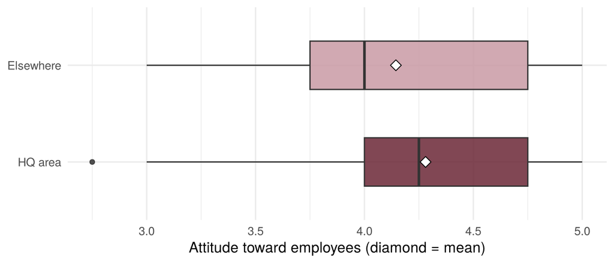

Figure 3: Attitude toward employees by residence

```r
efcu |>
  ggplot(aes(att_employee, residence, fill = residence)) +
  geom_boxplot(width = 0.5, show.legend = FALSE, alpha = 0.85) +
  stat_summary(fun = mean, geom = "point", shape = 23, size = 3, fill = "white") +
  scale_fill_manual(values = c(pal[1], pal[2])) +
  labs(x = "Attitude toward employees (diamond = mean)", y = NULL) +
  theme_minimal(base_size = 12)
```

## 4.2 R4b: Awareness of Services

Each awareness item has three ordered levels, so each is cross-tabulated with residence (dependent variable in the rows, column percentages within each residence group) and tested with a chi-square test of independence. Following Dr. Jung’s guidance, if any **expected** cell count falls below 5, the categories are **collapsed** into “used” vs. “not used” before testing.

**Show the R code**

```r
svc <- c(q13r = "Regular share accounts", q14r = "Special subaccounts",
         q15r = "Christmas club accounts", q16r = "Individual retirement accounts",
         q17r = "MasterCard credit cards", q18r = "Signature loans",
         q19r = "New car loans", q20r = "Late model car loans",
         q21r = "Older model car loans", q22r = "Household goods loans",
         q23r = "Recreational loans", q24r = "Share collateralized loans",
         q25r = "IRA loans", q26r = "Line of credit loans")

r4b <- map_dfr(names(svc), function(v) {
  aw <- factor(efcu[[v]], 1:3, c("Unaware", "Aware, not used", "Aware and used"))
  tab <- table(aw, efcu$residence)
  tab <- tab[rowSums(tab) > 0, , drop = FALSE]            # drop empty levels
  exp_min <- min(suppressWarnings(chisq.test(tab))$expected)
  collapsed <- exp_min < 5
  if (collapsed) {                                        # used vs. not used
    used <- factor(efcu[[v]] == 3, c(FALSE, TRUE), c("Not used", "Used"))
    tab <- table(used, efcu$residence)
  }
  chi <- suppressWarnings(chisq.test(tab, correct = FALSE))
  pct <- prop.table(table(factor(efcu[[v]], 1:3), efcu$residence), 2) * 100
  tibble(Service = svc[[v]],
         `HQ: unaware %` = pct[1, 1], `Elsewhere: unaware %` = pct[1, 2],
         `HQ: used %` = pct[3, 1], `Elsewhere: used %` = pct[3, 2],
         Test = if (collapsed) "Used vs. not used" else "3 levels",
         `χ²` = unname(chi$statistic), df = unname(chi$parameter), p = chi$p.value)
})

r4b |> mutate(across(c(ends_with("%"), `χ²`), ~ round(.x, 1)), p = fmt_p_tbl(p))
```

Table 7: Awareness of services by residence (column %) with chi-square tests of independence

| Service | HQ: unaware % | Elsewhere: unaware % | HQ: used % | Elsewhere: used % | Test | χ² | df | p |
| --- | --- | --- | --- | --- | --- | --- | --- | --- |
| Regular share accounts | 59.6 | 69.0 | 12.3 | 8.5 | 3 levels | 1.3 | 2 | 0.529 |
| Special subaccounts | 38.6 | 33.8 | 7.0 | 11.3 | 3 levels | 0.8 | 2 | 0.666 |
| Christmas club accounts | 29.8 | 35.2 | 8.8 | 8.5 | Used vs. not used | 0.0 | 1 | 0.949 |
| Individual retirement accounts | 28.1 | 26.8 | 24.6 | 21.1 | 3 levels | 0.3 | 2 | 0.849 |
| MasterCard credit cards | 17.5 | 7.0 | 43.9 | 43.7 | 3 levels | 3.8 | 2 | 0.150 |
| Signature loans | 7.0 | 1.4 | 14.0 | 15.5 | Used vs. not used | 0.1 | 1 | 0.818 |
| New car loans | 3.5 | 4.2 | 17.5 | 19.7 | Used vs. not used | 0.1 | 1 | 0.754 |
| Late model car loans | 14.0 | 5.6 | 10.5 | 11.3 | 3 levels | 2.6 | 2 | 0.269 |
| Older model car loans | 26.3 | 25.4 | 7.0 | 11.3 | 3 levels | 0.7 | 2 | 0.714 |
| Household goods loans | 33.3 | 25.4 | 8.8 | 8.5 | Used vs. not used | 0.0 | 1 | 0.949 |
| Recreational loans | 38.6 | 46.5 | 8.8 | 11.3 | 3 levels | 1.4 | 2 | 0.502 |
| Share collateralized loans | 54.4 | 53.5 | 1.8 | 1.4 | Used vs. not used | 0.0 | 1 | 0.875 |
| IRA loans | 63.2 | 59.2 | 0.0 | 5.6 | Used vs. not used | 3.3 | 1 | 0.069 |
| Line of credit loans | 0.0 | 0.0 | 35.1 | 39.4 | 3 levels | 0.3 | 1 | 0.613 |

**Show the R code**

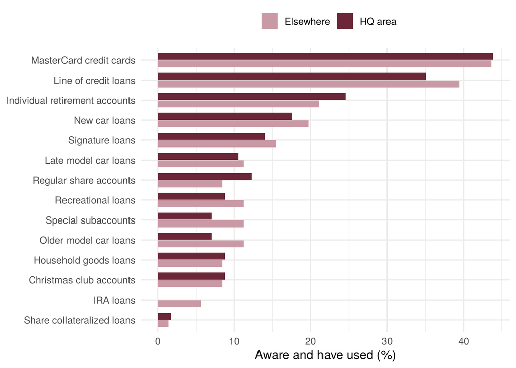

Figure 4: Percent of members who are aware of and have used each service, by residence

```r
r4b |>
  select(Service, `HQ area` = `HQ: used %`, Elsewhere = `Elsewhere: used %`) |>
  pivot_longer(-Service, names_to = "Residence", values_to = "pct") |>
  mutate(Service = fct_reorder(Service, pct)) |>
  ggplot(aes(pct, Service, fill = Residence)) +
  geom_col(position = position_dodge(width = 0.75), width = 0.7) +
  scale_fill_manual(values = c(`HQ area` = pal[1], Elsewhere = pal[2])) +
  labs(x = "Aware and have used (%)", y = NULL, fill = NULL) +
  theme_minimal(base_size = 12) + theme(legend.position = "top")
```

**R4b Insight**

Where members live makes **no meaningful difference** in how aware they are of credit union services: none of the 14 services shows a significant difference between HQ-area members and members elsewhere (all *p* > .05, Table 7). Both groups share the same pattern (Figure 4): the **MasterCard** and **line of credit** are the most used services, while large shares of both groups are **unaware** of regular share accounts, share collateralized loans, and IRA loans. Because the awareness gap is the same everywhere, the CU can run **one** awareness campaign for all members instead of targeting by location.

## 4.3 R4c: Operational Effectiveness

**Show the R code**

```r
r4c <- map_dfr(names(r6_labels), \(v) t2(v, r6_labels[[v]]))
r4c |> mutate(across(c(`HQ area M`, `Elsewhere M`, Difference, t), ~ round(.x, 2)),
              df = round(df, 1), p = fmt_p_tbl(p))
```

Table 8: Operational effectiveness items by residence: independent-samples (Welch) t-tests

| Item | HQ area M | Elsewhere M | Difference | t | df | p |
| --- | --- | --- | --- | --- | --- | --- |
| Q9r: Statement frequency (1 = never, 5 = too often) | 2.79 | 2.76 | 0.03 | 0.39 | 122.1 | 0.699 |
| Q10r: Statement accuracy (1 = poor, 4 = excellent) | 3.49 | 3.45 | 0.04 | 0.35 | 117.5 | 0.724 |
| Q31: Keeps my financial information confidential | 4.05 | 3.86 | 0.19 | 1.62 | 121.3 | 0.109 |
| Q32: Prompt in processing loans | 3.68 | 3.75 | -0.06 | -0.44 | 118.9 | 0.661 |
| Q33: Services meet members’ needs | 3.60 | 3.59 | 0.00 | 0.04 | 112.9 | 0.968 |
| Q34: Loan applications are simple | 3.28 | 3.61 | -0.32 | -2.28 | 94.2 | 0.025 |
| Q37r: Overall management (1 = very poor, 5 = excellent) | 4.02 | 4.10 | -0.09 | -0.66 | 118.7 | 0.513 |

**Show the R code**

```r
r4c_yn <- map_dfr(c(q11 = "Q11: Statements easy to understand",
                    q12 = "Q12: CU keeps account information confidential") |> imap(\(lab, v) c(v, lab)),
  function(x) {
    tab <- table(factor(efcu[[x[1]]], 1:2, c("Yes", "No")), efcu$residence)
    chi <- suppressWarnings(chisq.test(tab, correct = FALSE))
    fis <- fisher.test(tab)
    pct <- prop.table(tab, 2) * 100
    tibble(Item = x[2], `HQ area: yes %` = round(pct["Yes", 1], 1),
           `Elsewhere: yes %` = round(pct["Yes", 2], 1),
           `χ²(1)` = round(unname(chi$statistic), 2), `p (χ²)` = fmt_p_tbl(chi$p.value),
           `Min. expected` = round(min(chi$expected), 1),
           `p (Fisher's exact)` = fmt_p_tbl(fis$p.value))
  })
r4c_yn
```

Table 9: Yes/no items by residence (column %) with chi-square tests of independence

| Item | HQ area: yes % | Elsewhere: yes % | χ²(1) | p (χ²) | Min. expected | p (Fisher’s exact) |
| --- | --- | --- | --- | --- | --- | --- |
| Q11: Statements easy to understand | 96.5 | 98.6 | 0.61 | 0.435 | 1.3 | 0.585 |
| Q12: CU keeps account information confidential | 63.3 | 75.4 | 1.85 | 0.173 | 14.8 | 0.206 |

For Q11, only three members answered “no,” so expected cell counts fall below 5. Because a yes/no item cannot be collapsed further, Fisher’s exact test is reported as well.

**R4c Insight**

Members in both locations see operations **almost the same way** (Table 8, Table 9). The one exception is **loan applications**: members who live **elsewhere** find them simpler (*M* = 3.61) than HQ-area members do (*M* = 3.28; *t*(94.2) = -2.28, *p* = .025). Ratings of statements, confidentiality, loan speed, meeting needs, and overall management do not differ by residence (all *p* > .10). One possible reason is that HQ-area members are more likely to apply in person, so the CU should review its **in-branch loan application process** at headquarters and ask HQ-area members what makes it harder.

# 5 Summary of Insights

Table 10: Summary of findings

| RQ | Key insight | Implication for EFCU |
| --- | --- | --- |
| **R3** | Members rate employees very positively (mean 4.21 of 5); professionalism and availability are rated lowest. | Feature friendly, helpful staff in loan promotions; check staffing at peak times. |
| **R6** | The CU is seen as well run, but statements are not frequent enough for some members and about 30% doubt confidentiality (Q12). | Offer more frequent or online statements; communicate privacy safeguards. |
| **R4a** | Attitudes toward employees do not differ by residence. | Service quality is consistent; no location-specific fix needed. |
| **R4b** | Awareness of services does not differ by residence; gaps are shared. | Run one member-wide awareness campaign. |
| **R4c** | Only loan application simplicity differs: HQ-area members find it harder. | Simplify the loan application process at headquarters. |

# Appendix

## Project Links

- [GitHub Repository](https://github.com/jukedz/ibm6500-assignments/tree/main/IC-Case31-Summary-R3-R6-R4)
- [GitHub Pages Website](https://jukedz.github.io/ibm6500-assignments/IC-Case31-Summary-R3-R6-R4/julieta-diaz-case31-r3-r6-r4.html)